# 140.651 - Lab 1

9/1/2020 and 9/2/2020

# Administrative Notes

The TA’s for 651 and 652 for 2020-21 are:

- Marta Karas (mkaras2@jhmi.edu)
- Nathan Dyjack (ndyjack1@jhmi.edu)
- Jingning Zhang (jzhan218@jhu.edu)

Labs are held on:

- Tuesday 1:30 – 2:20pm (Marta Karas)
- Wednesday 9:30 – 10:20am (Marta Karas)

Office Hour:

- Tuesday 5:00-6:00PM (starting September 8th, 2020) (Jingning Zhang)

The Tuesday and Wednesday labs will contain the same material each week, so students may select which of the two labs they would like to attend.

Feel free to email any of us if you have any suggestions on what you would like to see more of in lab, if there is a particular topic or homework problem you would like to see reviewed in more depth in lab or office hours, or if none of the office hours work for you.

### Slack channel

Slack workspace **651-2 Methods in Biostatistics I-II [2020-21]** was set for this class. Slack is a collaboration platform that allows connecting people within a group or organization. Here, we have created Slack workspace to facilitate discussion within students themselves, as well as with TAs. We hope this chat platform would allow you to discuss and clarify lecture content, exam preparation sets, and homework.

[figure not shown]

To join the Slack workspace **651-2 Methods in Biostatistics I-II [2020-21]**, use the invite link: https://join.slack.com/t/1406512method-nsk7542/shared_invite/zt-gxo29jud-17hzkthER8lk3eH5JS1Lwg (will also be sent in a separate email).

Workspace **651-2 Methods in Biostatistics I-II [2020-21]** URL: https://app.slack.com/client/T019WBDPML4/D019M3DB39T.

### Homework - reminder

All homework has been posted on CoursePlus ahead of time with the expectation that problems are to be completed as the material is covered in lecture.

# Introduction to R

*Textbook reference: Chapter 2*

`R` is a powerful analytical language and contains a number of useful packages for analyzing data. In this class, we will use `R` to help tie theoretical concepts to applications.

`RStudio` is a free and open-source integrated development environment (IDE) for R. `RStudio` provides comprehensive facilities to `R` programmers and is highly recommended in this class.

## Installing `R`

To install `R`, visit http://cran.us.r-project.org and select `Mac` or `Windows` based on which device you have.

- For Mac users, you should check your operating system (OS) version and select the corresponding installation package. (You can check your OS version in `About This Mac > Overview` in the Apple menu.) The installation package is named along the lines of `R-4.0.2.pkg` (as of Aug 28, 2020).
- For Windows users, the above link will take you to a subdirectories page. Next to the `base` sub directory, click the linked text `install R for the first time`. This should take you to a page with a download link (`Download R 4.0.2 for Windows`) of a file named along the lines of `R-4.0.2-win.exe` (as of Aug 28, 2020).

Once the proper installation package has been selected, run the package and follow the on-screen directions. This installation includes the `R` language and a graphical user interface (GUI). Rather using the GUI, we recommend installing `RStudio` - an integrated development environment (IDE) that lets you interact with `R` with some added benefits.

## Installing `RStudio`

To install `RStudio`, visit http://www.rstudio.com. Once on the website, select `Download RStudio`, scroll down and click `Download` under the free version, and select the proper installation file for your platform (Windows or Mac).

There are four main windows.

- The **console** is the lower-left window where you can run lines of code and see the output.
- The **script window** is the upper-left window where you can edit and write scripts or markdown documents. From the script window, you can run the current line of code in your script (or multiple lines if you highlight multiple rows) by pressing
  - `CMD` + `Return` on Mac
  - `CTRL` + `Enter` on Windows
- The **workspace** is the upper-right window where you can manage your data and variables and see previous commands entered (under the history tab).
- The **plots** window allows you to see the output of plots. On the other tabs, you can also look at directories, install packages, and look at help files for various `R` commands.

You can customize the look of your RStudio IDE in `Tools > Global Options...`.

### `R` packages

Packages are the fundamental units of reproducible `R` code. They are collections of `R` code that typically share some common purpose. Examples:

- `dplyr` - package of functions for fast data set manipulation (subsetting, summarizing, rearranging, and joining together data sets)
- `ggplot2` - “R’s famous package for making beautiful graphics”; allows to build multiple-layers, highly custimizable plots

You may be interested in reviewing this [Quick list of useful R packages](https://support.rstudio.com/hc/en-us/articles/201057987-Quick-list-of-useful-R-packages)

## Basic `R` Commands

For good R coding style guides, view [Tidyverse Style Guide](https://style.tidyverse.org/) by Hadley Wickham.

### Evaluation and Order of Operations

```r
5 + 6
```

```
[1] 11
```

```r
6 / 7
```

```
[1] 0.8571429
```

```r
8 * 3
```

```
[1] 24
```

```r
(4 + 5) * 8 + sqrt(7)
```

```
[1] 74.64575
```

### Assigning Variables

```r
# Assign the value `5` to `x`
x <- 5
# Print the value of `x`
x
```

```
[1] 5
```

```r
# Assign the value `6` to `y`
# Note that we can use `=` as well as `<-` to assign values
y = 6
# Print the value of `y`
y
```

```
[1] 6
```

```r
# Evaluate `x + y`
x + y
```

```
[1] 11
```

```r
# Assign `x + y` to `z`
z <- x + y
# Print the value of `z`
z
```

```
[1] 11
```

```r
# Re-assign x
x <- -1000
# Note that the value of `z` does not change
z
```

```
[1] 11
```

### Matrices and Vectors

Matrices and vectors are two common structures in `R` used to store data. For other ways of storing data, see Chapter 2.7 of your textbook. In particular, matrices and vectors can only contain one type of data, e.g. all characters, all integers, etc. Vectors have one dimension while matrices have two.

Suppose we are interested in defining a vector of consecutive numbers from 1 through 10.

```r
# Pull up `help` page for the command `sequence`
help(seq)
# Generate a vector of consecutive numbers from 1 to 10
my.seq1 <- seq(1, 10, by = 1)
my.seq1
```

```
 [1]  1  2  3  4  5  6  7  8  9 10
```

```r
# Alternative way of generating the same vector
my.seq2 <- c(1:10)
my.seq2
```

```
 [1]  1  2  3  4  5  6  7  8  9 10
```

Now suppose we want to generate a 3x3 matrix with numbers 1 through 9.

```r
my.matrix.rows <- matrix(c(1:9), nrow = 3, ncol = 3)
my.matrix.rows
```

```
     [,1] [,2] [,3]
[1,]    1    4    7
[2,]    2    5    8
[3,]    3    6    9
```

```r
# Alternative way of populating a matrix; leads to a different matrix
my.matrix.cols <- matrix(c(1:9), nrow = 3, ncol = 3, byrow = TRUE)
my.matrix.cols
```

```
     [,1] [,2] [,3]
[1,]    1    2    3
[2,]    4    5    6
[3,]    7    8    9
```

Operations with matrices are conducted as follows,

```r
# Elementwise addition
my.matrix.rows + my.matrix.cols
```

```
     [,1] [,2] [,3]
[1,]    2    6   10
[2,]    6   10   14
[3,]   10   14   18
```

```r
# Elementwise multiplication
my.matrix.rows * my.matrix.cols
```

```
     [,1] [,2] [,3]
[1,]    1    8   21
[2,]    8   25   48
[3,]   21   48   81
```

```r
# Matrix multiplication
my.matrix.rows %*% my.matrix.cols
```

```
     [,1] [,2] [,3]
[1,]   66   78   90
[2,]   78   93  108
[3,]   90  108  126
```

We can access specific elements of a matrix using the following commands,

```r
# Select the first row of the matrix
my.matrix.rows[1,]
```

```
[1] 1 4 7
```

```r
# Select the first column of the matrix
my.matrix.rows[,1]
```

```
[1] 1 2 3
```

```r
# Select the element in the first row and third column of the matrix
my.matrix.rows[1,3]
```

```
[1] 7
```

Furthermore, we can sort and order the elements in vectors and matrices.

- `sort()` is useful for ordering vectors
- `order()` is useful for ordering matrices/data frames

```r
# Generate a random vector of numbers 1 through 10
rand.vector <- sample(1:10, 9, replace = F)
rand.vector
```

```
[1]  1  5  4  8  2  9 10  3  7
```

```r
# Sort the random vector
sort(rand.vector, decreasing = FALSE)
```

```
[1]  1  2  3  4  5  7  8  9 10
```

```r
# Generate a random matrix
rand.matrix <- matrix(rand.vector, nrow = 3, ncol = 3)
rand.matrix
```

```
     [,1] [,2] [,3]
[1,]    1    8   10
[2,]    5    2    3
[3,]    4    9    7
```

```r
# Return orderd vector of elements in the matrix
rand.matrix[order(rand.matrix)]
```

```
[1]  1  2  3  4  5  7  8  9 10
```

Some caution on performing arithmetic operations on vectors and matrices of different dimensions: If the longer vector is an integer multiple of the shorter vector, than `R` will not return an error. A similar situation happens with matrices.

```r
c(1:10)*10
```

```
 [1]  10  20  30  40  50  60  70  80  90 100
```

```r
c(1:10)*c(-1,1)
```

```
 [1] -1  2 -3  4 -5  6 -7  8 -9 10
```

```r
c(1:10)*c(-1,1,1)
```

```
 [1]  -1   2   3  -4   5   6  -7   8   9 -10
```

```r
matrix(1:20, ncol=2, byrow=FALSE)
```

```
      [,1] [,2]
 [1,]    1   11
 [2,]    2   12
 [3,]    3   13
 [4,]    4   14
 [5,]    5   15
 [6,]    6   16
 [7,]    7   17
 [8,]    8   18
 [9,]    9   19
[10,]   10   20
```

```r
matrix(1:20, ncol=2, byrow=FALSE)*c(1,2)
```

```
      [,1] [,2]
 [1,]    1   11
 [2,]    4   24
 [3,]    3   13
 [4,]    8   28
 [5,]    5   15
 [6,]   12   32
 [7,]    7   17
 [8,]   16   36
 [9,]    9   19
[10,]   20   40
```

```r
matrix(1:20, ncol=2, byrow=FALSE)*c(1,-1,1,-1)
```

```
      [,1] [,2]
 [1,]    1   11
 [2,]   -2  -12
 [3,]    3   13
 [4,]   -4  -14
 [5,]    5   15
 [6,]   -6  -16
 [7,]    7   17
 [8,]   -8  -18
 [9,]    9   19
[10,]  -10  -20
```

## Simulating and Plotting Data

### Normal Distribution

Suppose we are interested in sampling from the normal distribution.

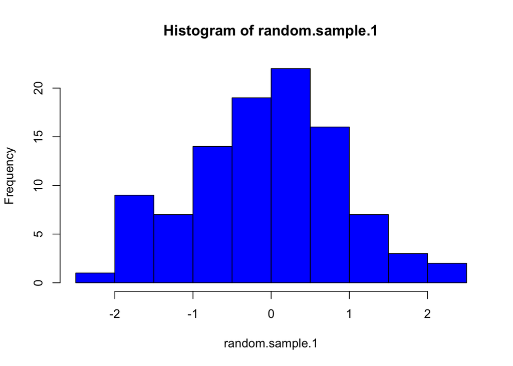

```r
# Set the random number generator seed to make simulation results reproducible
set.seed(55)
# Pull up the `help` page
help(rnorm)
?rnorm

# Simulate 100 random samples from a Normal(0, 1)
random.sample.1 <- rnorm(100, mean = 0, sd = 1)

# Plot a histogram of the 100 observations
hist(random.sample.1, col = 'blue')
```

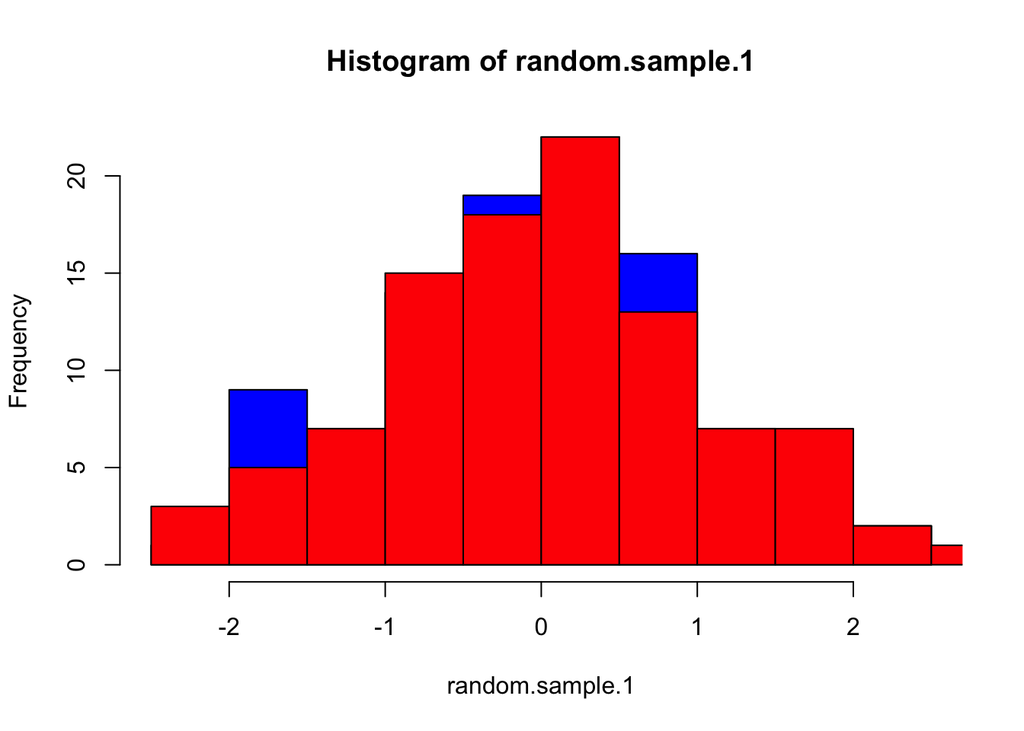

```r
# Simulate another 100 random samples from a normal(0, 1)
random.sample.2 <- rnorm(100, mean = 0, sd = 1)

# Add the histogram of the second 100 samples
hist(random.sample.1, col = 'blue')
hist(random.sample.2, add = TRUE, col = 'red')
```

Below are some additional ways to plot the data simulated from the normal distribution.

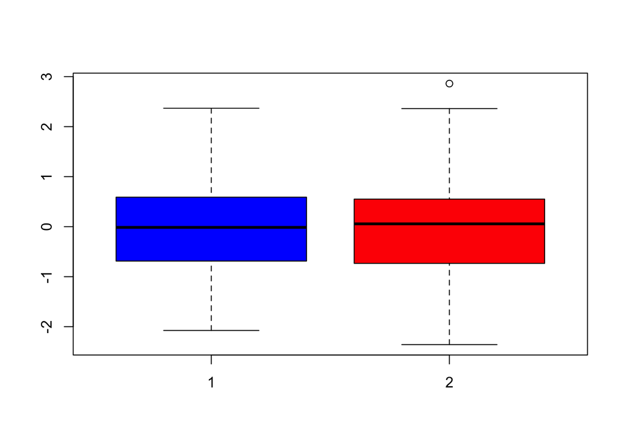

```r
# Boxplot
boxplot(random.sample.1, random.sample.2, col = c('blue', 'red'))
```

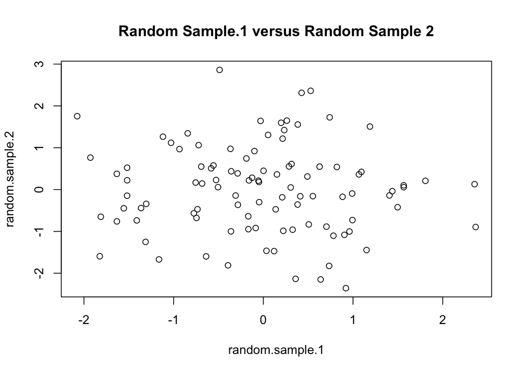

```r
# Plot
plot(random.sample.1, random.sample.2, main = 'Random Sample.1 versus Random Sample 2')
```

We can also generate summary statistics on the generated samples

```r
# Calculate the mean of each of the random samples
mean(random.sample.1)
```

```
[1] -0.03122864
```

```r
mean(random.sample.2)
```

```
[1] 0.008449625
```

```r
# Calculate the standard deviation
sd(random.sample.1)
```

```
[1] 0.9562888
```

```r
sd(random.sample.2)
```

```
[1] 1.050205
```

```r
# Calculate the min and max
min(random.sample.1)
```

```
[1] -2.075271
```

```r
max(random.sample.2)
```

```
[1] 2.860704
```

In addition to the Normal distribution, `R` has many other built-in distributions from which we can sample from. Some examples are the exponential distribution and the uniform distribution. We will explore more in the exercises.

## Changing the Working Directory, Saving, and Loading

We can tell `R` which folder we are working from by setting our working directory. We can use the following commands,

- For a mac, `setwd('/path/to/my/directory/')`
- for a PC, `setwd("c:/path/to/my/directory/")`

We can save, delete, and load objects from our work space for future use.

```r
# List variables in our workspace
ls()
```

```
 [1] "my.matrix.cols"  "my.matrix.rows"  "my.seq1"         "my.seq2"
 [5] "rand.matrix"     "rand.vector"     "random.sample.1" "random.sample.2"
 [9] "x"               "y"               "z"
```

```r
# Save objects from our workspace
save(random.sample.1, file = 'lab1.RData')

# Remove a object from the workspace
rm(random.sample.1)

# Remove ALL objects from the workspace (be careful with this!)
rm(list = ls())

# Check which working directory you are in
getwd()
```

```
[1] "/Users/martakaras/OneDrive - Johns Hopkins/651-652_TA_2020-21/2020_Labs/lab1"
```

```r
# Load the previously saved R data file
load('lab1.RData')
```

## Installing `R` package

To install an `R` package, run

```r
install.packages("replace_with_package_name")
# Example: install dplyr package
# install.packages("dplyr")
```

Once a package is installed, to use its contents in current `R` session, we run

```r
library(replace_with_package_name)
# Example: load dplyr package
# library(dplyr)
```

(Note the difference in presence of the quotation mark in the two above commands.)

## Exercises

### Ex. 1

For each of the exponential and uniform distribution, generate 100 random samples and visualize the data like we did above for the normal distribution.

### Ex. 2

Install the following `R` packages:

- `knitr`
- `rmarkdown`

Make sure you can execute the `library(...)` command on these two packages.

## Additional Resources

Below are some additional resources if you are interested in extra practice in `R`:

- Code School - http://www.codeschool.com/courses/try-r
- `R` Commands Reference Sheets - https://cran.r-project.org/doc/contrib/Short-refcard.pdf
- Alyssa Frazee (former TA, now a machine learning engineer at Stripe) - [Introducing R to a non-programmer in one hour](http://alyssafrazee.com/introducing-R.html)
- Coursera, Johns Hopkins Data Science, lectures can be viewed for free - https://www.coursera.org/specialization/jhudatascience/1/courses
- `R` for Beginners - http://cran.r-project.org/doc/contrib/Paradis-rdebuts_en.pdf